# Graph and Spatial Analysis of Iconography for Prehistory

Thomas Huet, Jose Pozo, Craig Alexander

2020-12-03

# Introduction

The R package `decorr` is used to study iconography with graph theory and spatial analysis indexes.

Its purpose is to contribute to cross-cultural iconography comparisons studies by a higher normalization of quantitative analysis (Huet and Alexander 2015). This package has been grounded on the seminal work of C. Alexander (Alexander 2008) and its first IT implementation by T. Huet (Huet 2018).

The main principle of `decorr` package is to considerate any iconographic compositions (here, ‘decorations’) as relative neighborhood graphs (RNG) where the nodes are the graphical units (GUs) sharing an edge one with another (edges) when their Voronoi cell share a border. The RNG covers all the GUs, so the decoration is considered as a 1-component graph. Before the analysis process, contemporaneous and non-contemporaneous GUs can be studied separately.

Buidling decoration graphs in a GIS is already a spatial database of the iconographic content. Furthermore, it facilitate the data recording, with snapping options for example to connect GUs (nodes) with lines (edges), and allows to combine analyses coming from Graph theory and GIS management.

# Install

Install the `decorr` package from GitHub and load it.

```r
# devtools::install_github("zoometh/iconr")
library(decorr)
```

## Contents

The R package `decorr` is composed by functions and a dataset example (external data). All the drawings presented here have been first published by M. Diaz-Guardamino (Diaz-Guardamino 2010)

### Functions

Functions are provided to manage nodes (`nds`), edges (`eds`) and graphs (`grph`).

```r
cat(ls("package:decorr"), sep="\n")
```

```
#> contemp_nds
#> disambiguate_duplicates
#> eds_compar
#> grDeviceOpen
#> labels_shadow
#> list_compar
#> list_dec
#> named_edges
#> named_nodes
#> nds_compar
#> plot_compar
#> plot_dec_grph
#> read_eds
#> read_nds
#> same_elements
#> side_plot
```

### Data

External data give a training dataset to illustrate the package main functions.

The current path of training external data is the `extdata` folder of the package. Change this working directory for your own directory.

```r
# dataDir <- "C:/Documents/decorr/inst/extdata/"
dataDir <- system.file("extdata", package = "decorr")
cat(list.files(dataDir),sep="\n")
```

```
#> Brozas.Brozas.jpg
#> Cerro_Muriano.Cerro_Muriano_1.jpg
#> Ibahernando.Ibahernando.jpg
#> Torrejon_Rubio.Torrejon_Rubio_1.jpg
#> Zarza_de_Montanchez.Zarza_de_Montanchez.jpg
#> edges.csv
#> edges.dbf
#> edges.shp
#> edges.shx
#> edges.tsv
#> imgs.csv
#> imgs.tsv
#> nodes.csv
#> nodes.dbf
#> nodes.shp
#> nodes.shx
#> nodes.tsv
```

Each decoration is a set of:

- a drawing/image (`.jpg`)
- a dataframe of decoration identifiers (`.tsv` or `.csv`)
- a dataframe of nodes (`.tsv`, `.csv` or `.shp`)
- a dataframe of edges (`.tsv`, `.csv` or `.shp`)

Since a GIS interface is often the most practicale to record nodes and edges, the package has been designed to accept shapefiles (`.shp`) for nodes (`POINTS` geometries) and edges (`LINES` geometries). Tabular data can be `.tsv` (tab-separated values) or `.csv` (semicolons-separated values)

#### Drawings/Images

For a given decoration, its drawing (ie, images, raster, grid) is the space of reference of the graph: nodes and edges inherit their coordinates from the decoration grid. Identifiers and paths to images are stored in the `imgs` dataframe

```r
imgs_path <- paste0(dataDir, "/imgs.tsv")
imgs <- read.table(imgs_path, sep="\t", stringsAsFactors = FALSE)
knitr::kable(imgs, "html") %>%
  kable_styling(full_width = FALSE, position = "center", font_size=12)
```

| idf | site | decor | img |
| --- | --- | --- | --- |
| 1 | Cerro Muriano | Cerro Muriano 1 | Cerro_Muriano.Cerro_Muriano_1.jpg |
| 2 | Torrejon Rubio | Torrejon Rubio 1 | Torrejon_Rubio.Torrejon_Rubio_1.jpg |
| 3 | Brozas | Brozas | Brozas.Brozas.jpg |
| 4 | Zarza de Montanchez | Zarza De Montanchez | Zarza_de_Montanchez.Zarza_De_Montanchez.jpg |
| 5 | Ibahernando | Ibahernando | Ibahernando.Ibahernando.jpg |

The decorations unique identifiers are the concatenation of the site name and decoration name. For example, the name of the `Cerrano Muriano 1` decoration is `Cerro_Muriano.Cerro_Muriano_1.jpg`.

Drawing/images (`.jpg`) are mostly managed with the R [`magick-image` package](https://cran.r-project.org/web/packages/magick/vignettes/intro.html)

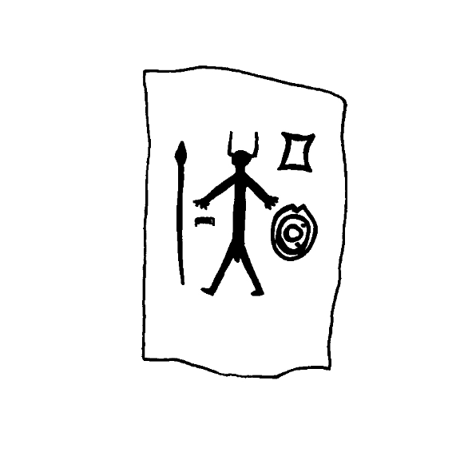

Cerro_Muriano.Cerro_Muriano_1.jpg

Nodes are located approximatively on the centroid of GUs. The R [`igraph` package](https://igraph.org/r/) allow further network analysis. Other spatial analysis can be performed on a GIS.

#### Nodes

Nodes (ie, vertices) are stored in a dataframe (`.csv` or `.tsv`) or a shapefile (`.shp`). If the input data come from a dataframe, coordinates columns `x` and `y` are required

```r
nds.df <- read_nds(site = "Cerro Muriano", decor = "Cerro Muriano 1", doss = dataDir)
knitr::kable(nds.df, "html") %>%
  kable_styling(full_width = FALSE, position = "center", font_size=12)
```

| site | decor | id | type | x | y |
| --- | --- | --- | --- | --- | --- |
| Cerro Muriano | Cerro Muriano 1 | 1 | personnage | 349.8148 | -298.3244 |
| Cerro Muriano | Cerro Muriano 1 | 2 | casque | 349.8148 | -243.9851 |
| Cerro Muriano | Cerro Muriano 1 | 3 | lance | 238.4637 | -298.3244 |
| Cerro Muriano | Cerro Muriano 1 | 4 | bouclier | 446.0222 | -381.1697 |
| Cerro Muriano | Cerro Muriano 1 | 5 | peigne | 283.0041 | -358.0086 |
| Cerro Muriano | Cerro Muriano 1 | 7 | sexe_masculin | 342.6884 | -427.4917 |
| Cerro Muriano | Cerro Muriano 1 | 8 | lingot_pdb | 451.1489 | -237.4782 |

- column names
- `site`: decoration site
- `decor`: decoration name
- `id`: id of the edges (a unique number)
- `type`: type of the nodes
- `x, y`: coordinates of the nodes

#### Edges

Edges are stored in a dataframe (`.csv` or `.tsv`) or a shapefile (`.shp`). If the input data is a dataframe, coordinates columns `xa` and `ya` (origins of the edges), `xb` and `yb` (ends of the edges) are required.

```r
eds.df <- read_eds(site = "Cerro Muriano", decor = "Cerro Muriano 1", doss = dataDir)
knitr::kable(eds.df, "html") %>%
  kable_styling(full_width = FALSE, position = "center", font_size=12)
```

a

b

type

xa

ya

xb

yb

Cerro Muriano

Cerro Muriano 1

1

4

=

349.8148

-298.3244

446.0222

-381.1697

Cerro Muriano

Cerro Muriano 1

1

5

=

349.8148

-298.3244

283.0041

-358.0086

Cerro Muriano

Cerro Muriano 1

3

5

=

238.4637

-298.3244

283.0041

-358.0086

Cerro Muriano

Cerro Muriano 1

1

2

349.8148

-298.3244

349.8148

-243.9851

Cerro Muriano

Cerro Muriano 1

1

7

349.8148

-298.3244

342.6884

-427.4917

Cerro Muriano

Cerro Muriano 1

3

1

=

238.4637

-298.3244

349.8148

-298.3244

Cerro Muriano

Cerro Muriano 1

1

8

=

349.8148

-298.3244

451.1489

-237.4782

Cerro Muriano

Cerro Muriano 1

4

8

=

446.0222

-381.1697

451.1489

-237.4782

column names

`site`: decoration site

`decor`: decoration name

`id`: id of the edge (a unique number)

`a`: *id* of the first node

`b`: *id* of the second node

`type`: Edges types

`=`: [*normal* edges][] (undirected)

`+`: [*attribute* edges][], node `b` is an attribute of node `a` (directed)

`>`: [*overlap* edges][], node `a` overlaps node `b` (directed)

`xa, ya`: coordinates of the first node (`a`)

`xb, yb`: coordinates of the second node (`b`)

##### Edges types

By default, all comtemporaneous GUs are linked with edges are displayed in **orange**. At the opposite, GUs coming from different periods are linked with **blue** edges.

Except the *normal* edges which is undirected, the *attribute* and *overlap* edges are directed. That is to say, that for *attribute* and *overlap* edges `1-*-2`, where `*` could be either `+` or `>`, is not equal to `2-*-1`.

- *normal* edges

Usually, differents GUs considerated as contemporaneous and close one with another, shared an edge with the value `=` for their `type`. By convention, these edges are called ‘*normal*’ and displayed with a plain line.

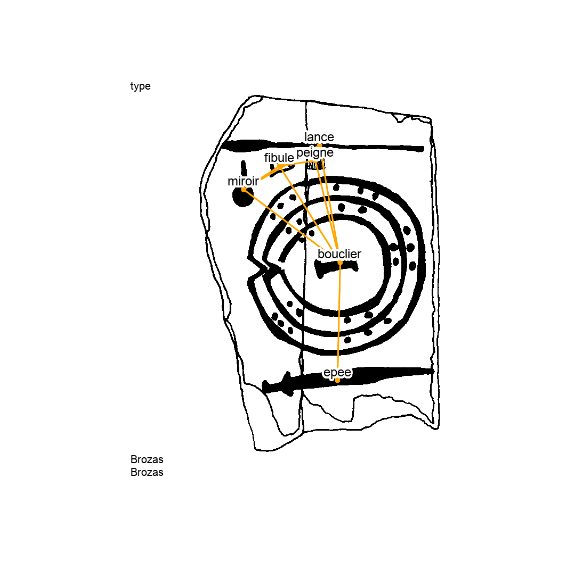

Brozas decoration, normal edges

```r
nds.df <- read_nds(site = "Brozas",
                   decor = "Brozas",
                   doss = dataDir)
eds.df <- read_eds(site = "Brozas",
                   decor = "Brozas",
                   doss = dataDir)
img.graph <- plot_dec_grph(nodes = nds.df,
                           edges = eds.df,
                           site = "Brozas",
                           decor = "Brozas",
                           nds.lbl = 'type',
                           lbl.size = 2,
                           doss = dataDir)
plot(img.graph)
```

- *attribute* edges

When a GU is an attribute of another, edges are identified with a `+` and displayed with a dashed line. For example, at the bottom of the `Zarza De Montanchez` decoration, the main GU chariot `7` is connected with four GUs attributes (or secondary GUs):

- two horses (cheval): `8` and `9`
- two wheels (roue): `10` and `11`

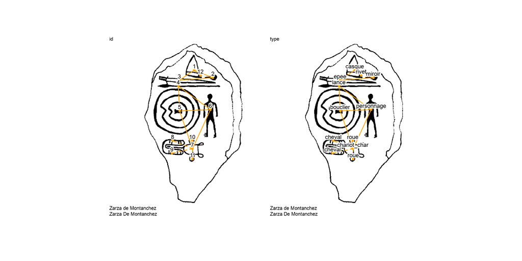

Zarza De Montanchez decoration, normal and attribute edges

```r
nds.df <- read_nds(site = "Zarza de Montanchez",
                   decor = "Zarza De Montanchez",
                   doss = dataDir)
eds.df <- read_eds(site = "Zarza de Montanchez",
                   decor = "Zarza De Montanchez",
                   doss = dataDir)
img.graph.id <- plot_dec_grph(nodes = nds.df,
                              edges = eds.df,
                              site = "Zarza de Montanchez",
                              decor = "Zarza De Montanchez",
                              lbl.size = 2,
                              doss = dataDir)
img.graph.type <- plot_dec_grph(nodes = nds.df,
                                edges = eds.df,
                                site = "Zarza de Montanchez",
                                decor = "Zarza De Montanchez",
                                nds.lbl = 'type',
                                lbl.size = 2,
                                doss = dataDir)
img.attributes <- image_append(c(img.graph.id,img.graph.type))
plot(img.attributes)
```

For example, the edge between the GUs `7` and `8` (respectively the chariot and a horse) is:

```r
eds.df <- read_eds(site = "Zarza de Montanchez", decor = "Zarza De Montanchez", doss = dataDir)
cat(paste0(eds.df[8,"a"]," -",eds.df[8,"type"],"- ",eds.df[8,"b"]))
```

```
#> 7 -+- 8
```

- *overlapping* edges

When a GU overlaps another – or is more recent than antother – edges ae identified with a `>` and displayed with a blue plain line. For example, the `Ibahernando` stelae show a latin writing (écriture) overlapping a spear (lance) and a shield (bouclier).

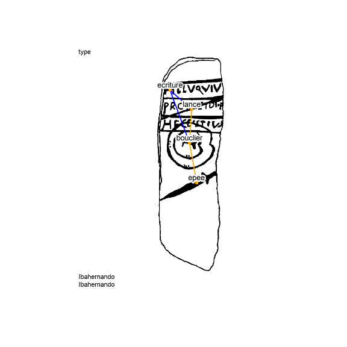

Ibahernando decoration, normal and overlap edges

```r
nds.df <- read_nds(site = "Ibahernando",
                   decor = "Ibahernando",
                   doss = dataDir)
eds.df <- read_eds(site = "Ibahernando",
                   decor = "Ibahernando",
                   doss = dataDir)
img.graph <- plot_dec_grph(nodes = nds.df,
                           edges = eds.df,
                           site = "Ibahernando",
                           decor = "Ibahernando",
                           nds.lbl = 'type',
                           lbl.size = 2,
                           doss = dataDir)
plot(img.graph)
```

For example, the edge between the GUs `1` and `2` (respectively the writing and the spear) is:

```r
eds.df <- read_eds(site = "Ibahernando", decor = "Ibahernando", doss = dataDir)
cat(paste0(eds.df[1,"a"]," -",eds.df[1,"type"],"- ",eds.df[1,"b"]))
```

```
#> 1 ->- 2
```

## Examples

### Plot decoration graph

Plot `Cerro Muriano 1` nodes and edges for the field `type` with brown labels, nodes and edges

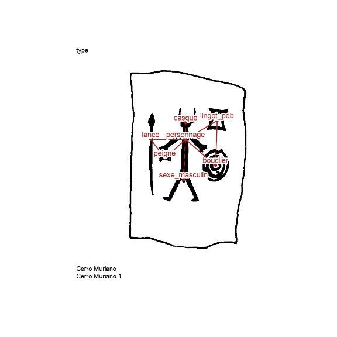

```r
# setwd(system.file("extdata", package = "decorr"))
nds.df <- read_nds(site = "Cerro Muriano", decor = "Cerro Muriano 1", doss = dataDir)
eds.df <- read_eds(site = "Cerro Muriano", decor = "Cerro Muriano 1", doss = dataDir)
img.graph <- plot_dec_grph(nodes = nds.df,
                           edges = eds.df,
                           site = "Cerro Muriano",
                           decor = "Cerro Muriano 1",
                           nds.lbl = 'type',
                           nd.color = "brown",
                           lbl.color = "brown",
                           eds.color = "brown",
                           lbl.size=2,
                           doss = dataDir)
plot(img.graph)
```

Replot the graph with `id` field instead of the `type` field

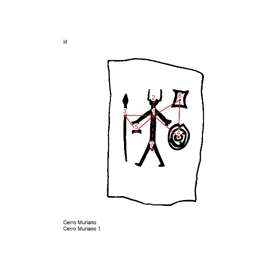

```r
# setwd(system.file("extdata", package = "decorr"))
nds.df <- read_nds(site = "Cerro Muriano", decor = "Cerro Muriano 1", doss = dataDir)
eds.df <- read_eds(site = "Cerro Muriano", decor = "Cerro Muriano 1", doss = dataDir)
img.graph <- plot_dec_grph(nodes = nds.df,
                           edges = eds.df,
                           site = "Cerro Muriano",
                           decor = "Cerro Muriano 1",
                           nds.lbl = 'id',
                           nd.color = "brown",
                           lbl.color = "brown",
                           eds.color = "brown",
                           lbl.size=2,
                           doss = dataDir)
plot(img.graph)
```

### Compare decoration graphs

Between all the graphs, or between a pair of graphs, nodes and edges can be compared with the function `same_elements()` and `plot_compar()`.  
By default, between a pairwise of decorations, common nodes and edges are displayed in red, but their colors – and other graphical parameters – can be modified.

#### Common elements

Comparison is one of the key-stone of archaeology. With the `same_elements()` function – preparing the data for further analysis – and the `plot_compar()` function – for graphical outputs –, comparison of graphical contents between pairwises of decorations can be done on the two elements of a graph: nodes and edges.

##### Common nodes

A classic study in archaeological research is to count the common GUs between decoration pairwises. This can be done with the `same_elements()` function with a node focus (`focus = "nodes"`), and considering for example their `type`.

```r
imgs_path <- paste0(dataDir, "/imgs.tsv")
nodes_path <- paste0(dataDir, "/nodes.tsv")
edges_path <- paste0(dataDir, "/edges.tsv")
imgs <- read.table(imgs_path, sep="\t", stringsAsFactors = FALSE)
nodes <- read.table(nodes_path, sep="\t", stringsAsFactors = FALSE)
edges <- read.table(edges_path, sep="\t", stringsAsFactors = FALSE)
lgrph <- list_dec(imgs, nodes, edges) # call function
df.same_nodes <- same_elements(lgrph,
                               focus = "nodes",
                               nds.var = "type")
knitr::kable(df.same_nodes, row.names = TRUE)
```

|  | 1 | 2 | 3 | 4 | 5 |
| --- | --- | --- | --- | --- | --- |
| 1 | 7 | 2 | 3 | 4 | 2 |
| 2 | 2 | 12 | 5 | 9 | 3 |
| 3 | 3 | 5 | 6 | 4 | 3 |
| 4 | 4 | 9 | 4 | 12 | 3 |
| 5 | 2 | 3 | 3 | 3 | 4 |

The results of `same_elements()` is a symetrical dataframe where row names and column headers are the identifiers of the decorations. Cells of the dataframe show the total number of common nodes by decoration pairwises, and the diagonal of the matrix shows the total number of nodes or edges of a given decoration. For example, the decoration `4` has 12 nodes, shares nine (9) nodes having the same `type` (common nodes) with the decoration `2` and shares four (4) nodes having the same `type` with the decoration `3`.

After the selection of the `type` variable in the `list_compar()` function, the `plot_compar()` function allows to plot these nodes having same `type` (common nodes) between each selected pairwise of decorations.

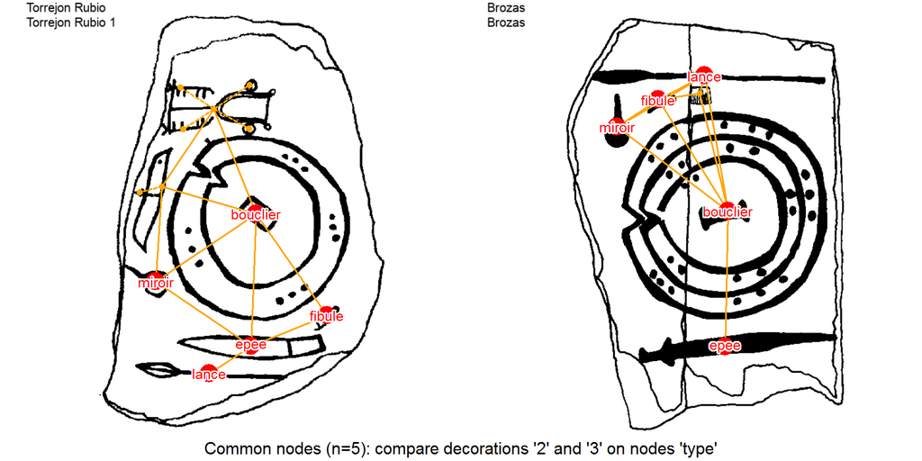

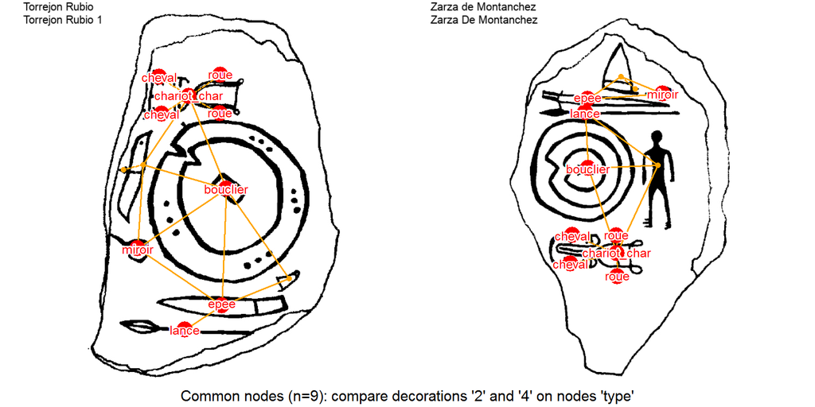

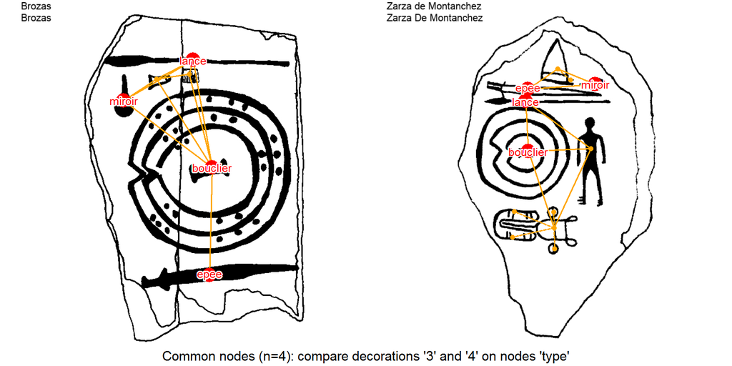

```r
# set wd to data folder
# out.img path is only useful to open the output image
dec.to.compare <- c(2, 3, 4)
# out.img <- paste0(dataDir,"/compar_nds_", dec.to.compare[1],"_",dec.to.compare[2],".png")
# read data
imgs_path <- paste0(dataDir, "/imgs.tsv")
nodes_path <- paste0(dataDir, "/nodes.tsv")
edges_path <- paste0(dataDir, "/edges.tsv")
imgs <- read.table(imgs_path, sep="\t", stringsAsFactors = FALSE)
nodes <- read.table(nodes_path, sep="\t", stringsAsFactors = FALSE)
edges <- read.table(edges_path, sep="\t", stringsAsFactors = FALSE)
lgrph <- list_dec(imgs, nodes, edges)
g.compar <- list_compar(lgrph, nds.var = "type")
nds_compar <- plot_compar(listg = g.compar,
                          graph2 = dec.to.compare,
                          focus = "nodes",
                          nds.size = c(0.5, 1.5),
                          doss = dataDir)
# open image
knitr::include_graphics(nds_compar)
```

The function creates an image for each pairwise of stelae contained in the `dec.to.compare` variable (2, 3, 4), with a focus on nodes (`focus = "nodes"`). That is to say $\frac{n!}{(n-2)!2!}$ pairwise comparisons, when `n` is the number of compared decoration.

#### Common Edges

A not so classic study in archaeological research is to count the common edges between decorations pairwise. The `same_elements()` function with an edge focus (`focus = "edges"`) create another dataframe where cells show the total number of common edges by decorations, and the diagonal is the total number of a given decoration. As previously, here it is the `type` of the nodes which is considered.

```r
imgs_path <- paste0(dataDir, "/imgs.tsv")
nodes_path <- paste0(dataDir, "/nodes.tsv")
edges_path <- paste0(dataDir, "/edges.tsv")
imgs <- read.table(imgs_path, sep="\t", stringsAsFactors = FALSE)
nodes <- read.table(nodes_path, sep="\t", stringsAsFactors = FALSE)
edges <- read.table(edges_path, sep="\t", stringsAsFactors = FALSE)
lgrph <- list_dec(imgs, nodes, edges) # call function
df.same_edges <- same_elements(lgrph, nds.var = "type", focus = "edges")
knitr::kable(df.same_edges,row.names = T)
```

|  | 1 | 2 | 3 | 4 | 5 |
| --- | --- | --- | --- | --- | --- |
| 1 | 8 | 0 | 1 | 2 | 0 |
| 2 | 0 | 15 | 3 | 7 | 1 |
| 3 | 1 | 3 | 10 | 1 | 2 |
| 4 | 2 | 7 | 1 | 14 | 1 |
| 5 | 0 | 1 | 2 | 1 | 4 |

Here, we read that the decoration `2` has fiftheen (15) edges, and share three (3) common edges with the decoration `3`. To show them, we use the `plot_compar()` function with an edge focus.

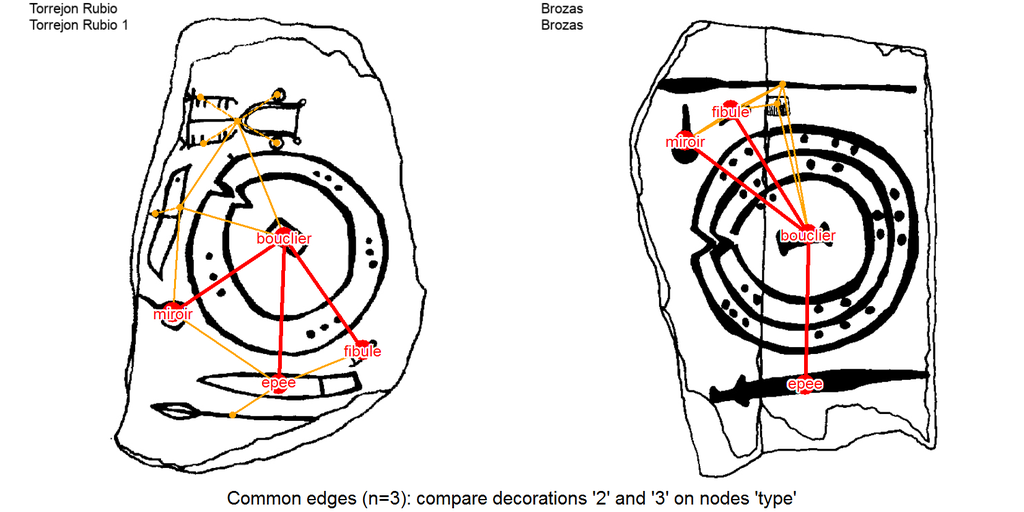

```r
dec.to.compare <- c(2,3)
# out.img <- paste0(dataDir,"/compar_eds_",dec.to.compare[1],"_",dec.to.compare[2],".png")
# read data
imgs_path <- paste0(dataDir, "/imgs.tsv")
nodes_path <- paste0(dataDir, "/nodes.tsv")
edges_path <- paste0(dataDir, "/edges.tsv")
imgs <- read.table(imgs_path, sep="\t", stringsAsFactors = FALSE)
nodes <- read.table(nodes_path, sep="\t", stringsAsFactors = FALSE)
edges <- read.table(edges_path, sep="\t", stringsAsFactors = FALSE)
lgrph <- list_dec(imgs, nodes, edges) # call function
g.compar <- list_compar(lgrph, nds.var = "type")
eds_compar <- plot_compar(listg = g.compar,
                          graph2 = dec.to.compare,
                          focus = "edges",
                          nds.size = c(0.5, 1.5),
                          doss = dataDir)
# open image
knitr::include_graphics(eds_compar)
```

#### Contemporaneous iconographical contents

It occurs that some GUs are non-contemporaneous one with the others, like for the latin writing overlapping Late Bronze Age engravings on Ibahernando stelae (see [*overlap* edges][]). In this case, the **non-contemporaneous layers of decoration should be removed before the comparison process**. To do so, the original graph (1-component) will be splitted on `->-` edges into different sub-graphs (n-component). Then, the studied graph component will be selected by passing a selected GU belonging to this component in the `contemp_nds()` function parameters.

For example, if we want to study the Late Bronze Age iconographic layer of Ibahernando stelae, we can choose the Late Bronze Age GU numbered 3,

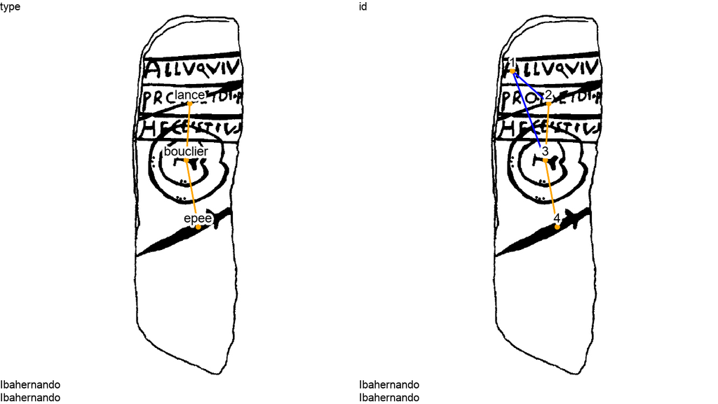

```r
selected.nd <- 3
nds.df <- read_nds(site = "Ibahernando",
                   decor = "Ibahernando",
                   doss = dataDir)
eds.df <- read_eds(site = "Ibahernando",
                   decor = "Ibahernando",
                   doss = dataDir)
l_dec_df <- contemp_nds(nds.df, eds.df, selected.nd)
Ibahernando.contemp <- plot_dec_grph(nodes = l_dec_df[[1]],
                                     edges = l_dec_df[[2]],
                                     site = "Ibahernando",
                                     decor = "Ibahernando",
                                     nds.lbl = "type",
                                     lbl.size=2,
                                     doss = dataDir)
Ibahernando <- plot_dec_grph(nodes = nds.df,
                             edges = eds.df,
                             site = "Ibahernando",
                             decor = "Ibahernando",
                             nds.lbl = "id",
                             lbl.size=2,
                             doss = dataDir)
image_append(c(Ibahernando.contemp, Ibahernando))
```

# References

Alexander, Craig. 2008. “The Bedolina Map – an Exploratory Network Analysis.” *Layers of Perception. Proceedings of the 35th International Conference on Computer Applications and Quantitative Methods in Archaeology (CAA), Berlin, 2.-6. April 2007*, 366–71.

Diaz-Guardamino, Marta. 2010. “Las Estelas Decoradas En La Prehistoria de La Pen{'}nsula Ib{'e}rica.”

Huet, Thomas. 2018. “Geometric Graphs to Study Ceramic Decoration.” *Proceedings of the 44th Conference on Computer Applications and Quantitative Methods in Archaeology, CAA 2016*, 311–24. https://www.researchgate.net/publication/343514122_Geometric_graphs_to_study_ceramic_decoration.

Huet, Thomas, and Craig Alexander. 2015. “Méthodes Informatiques Pour L’étude Des Gravures Rupestres : Les Exemples Du Valcamonica (Italie) et Du Mont Bego (France).” *Recherches Sur L’âge Du Bronze, Nouvelles Approches et Perspectives, Actes de La Journée d’étude de L’Association Pour La Promotion Des Recherches Archéologiques Sur L’âge Du Bronze, 28 Février 2014, Saint-Germain-En-Laye*, 15–29.